{% raw %}

{% endraw %} {% raw %}

{% endraw %} {% raw %}

```python
from fastai.data.external import *
```

{% endraw %} {% raw %}

{% endraw %} {% raw %}

```python
#TODO: investigate
```

{% endraw %}

## Helpers

{% raw %}

{% endraw %} {% raw %}

```python
im = Image.open(TEST_IMAGE).resize((30,20))
```

{% endraw %} {% raw %}

{% endraw %} {% raw %}

`None`[source]

{% endraw %} {% raw %}

{% endraw %}

#### `Image.n_px`

> `Image.n_px` (property)

Number of pixels in image

{% raw %}

```python
test_eq(im.n_px, 30*20)
```

{% endraw %} {% raw %}

`None`[source]

{% endraw %} {% raw %}

{% endraw %}

#### `Image.shape`

> `Image.shape` (property)

Image (height,width) tuple (NB:opposite order of `Image.size()`, same order as numpy array and pytorch tensor)

{% raw %}

```python
test_eq(im.shape, (20,30))
```

{% endraw %} {% raw %}

`None`[source]

{% endraw %} {% raw %}

{% endraw %}

#### `Image.aspect`

> `Image.aspect` (property)

Aspect ratio of the image, i.e. `width/height`

{% raw %}

```python
test_eq(im.aspect, 30/20)
```

{% endraw %} {% raw %}

{% endraw %} {% raw %}

`Image.reshape`[[source]](https://github.com/fastai/fastai/tree/master/fastai/vision/core.py#L47)

> `Image.reshape`(**`x`**:`Image.Image`, **`h`**, **`w`**, **`resample`**=*`0`*)

`resize` `x` to `(w,h)`

{% endraw %} {% raw %}

```python
test_eq(im.reshape(12,10).shape, (12,10))
```

{% endraw %} {% raw %}

{% endraw %} {% raw %}

`Image.to_bytes_format`[[source]](https://github.com/fastai/fastai/tree/master/fastai/vision/core.py#L53)

> `Image.to_bytes_format`(**`im`**:`Image.Image`, **`format`**=*`'png'`*)

Convert to bytes, default to PNG format

{% endraw %} {% raw %}

{% endraw %} {% raw %}

`Image.to_thumb`[[source]](https://github.com/fastai/fastai/tree/master/fastai/vision/core.py#L61)

> `Image.to_thumb`(**`h`**, **`w`**=*`None`*)

Same as `thumbnail`, but uses a copy

{% endraw %} {% raw %}

{% endraw %} {% raw %}

```python
test_eq(im.resize_max(max_px=20*30).shape, (20,30))
test_eq(im.resize_max(max_px=300).n_px, 294)
test_eq(im.resize_max(max_px=500, max_h=10, max_w=20).shape, (10,15))
test_eq(im.resize_max(max_h=14, max_w=15).shape, (10,15))
test_eq(im.resize_max(max_px=300, max_h=10, max_w=25).shape, (10,15))
```

{% endraw %} {% raw %}

`Image.resize_max`[[source]](https://github.com/fastai/fastai/tree/master/fastai/vision/core.py#L70)

> `Image.resize_max`(**`x`**:`Image.Image`, **`resample`**=*`0`*, **`max_px`**=*`None`*, **`max_h`**=*`None`*, **`max_w`**=*`None`*)

`resize` `x` to `max_px`, or `max_h`, or `max_w`

{% endraw %}

## Basic types

This section regroups the basic types used in vision with the transform that create objects of those types.

{% raw %}

`to_image`[[source]](https://github.com/fastai/fastai/tree/master/fastai/vision/core.py#L80)

> `to_image`(**`x`**)

Convert a tensor or array to a PIL int8 Image

{% endraw %} {% raw %}

{% endraw %} {% raw %}

`load_image`[[source]](https://github.com/fastai/fastai/tree/master/fastai/vision/core.py#L88)

> `load_image`(**`fn`**, **`mode`**=*`None`*)

Open and load a `PIL.Image` and convert to `mode`

{% endraw %} {% raw %}

{% endraw %} {% raw %}

`image2tensor`[[source]](https://github.com/fastai/fastai/tree/master/fastai/vision/core.py#L96)

> `image2tensor`(**`img`**)

Transform image to byte tensor in `c*h*w` dim order.

{% endraw %} {% raw %}

{% endraw %} {% raw %}

`class` `PILBase`[[source]](https://github.com/fastai/fastai/tree/master/fastai/vision/core.py#L103)

> `PILBase`() :: `Image`

This class represents an image object. To create :py:class:`~PIL.Image.Image` objects, use the appropriate factory functions. There's hardly ever any reason to call the Image constructor directly.

- :py:func:`~PIL.Image.open`

- :py:func:`~PIL.Image.new`

- :py:func:`~PIL.Image.frombytes`

{% endraw %} {% raw %}

{% endraw %} {% raw %}

`class` `PILImage`[[source]](https://github.com/fastai/fastai/tree/master/fastai/vision/core.py#L124)

> `PILImage`() :: `PILBase`

This class represents an image object. To create :py:class:`~PIL.Image.Image` objects, use the appropriate factory functions. There's hardly ever any reason to call the Image constructor directly.

- :py:func:`~PIL.Image.open`

- :py:func:`~PIL.Image.new`

- :py:func:`~PIL.Image.frombytes`

{% endraw %} {% raw %}

{% endraw %} {% raw %}

`class` `PILImageBW`[[source]](https://github.com/fastai/fastai/tree/master/fastai/vision/core.py#L127)

> `PILImageBW`() :: `PILImage`

This class represents an image object. To create :py:class:`~PIL.Image.Image` objects, use the appropriate factory functions. There's hardly ever any reason to call the Image constructor directly.

- :py:func:`~PIL.Image.open`

- :py:func:`~PIL.Image.new`

- :py:func:`~PIL.Image.frombytes`

{% endraw %} {% raw %}

{% endraw %} {% raw %}

```python
im = PILImage.create(TEST_IMAGE)
test_eq(type(im), PILImage)
test_eq(im.mode, 'RGB')
test_eq(str(im), 'PILImage mode=RGB size=1200x803')
```

{% endraw %} {% raw %}

```python
im.resize((64,64))
```

{% endraw %} {% raw %}

```python
ax = im.show(figsize=(1,1))
```

{% endraw %} {% raw %}

```python
test_fig_exists(ax)
```

{% endraw %} {% raw %}

```python
timg = TensorImage(image2tensor(im))
tpil = PILImage.create(timg)
```

{% endraw %} {% raw %}

```python
tpil.resize((64,64))
```

{% endraw %} {% raw %}

`class` `PILMask`[[source]](https://github.com/fastai/fastai/tree/master/fastai/vision/core.py#L130)

> `PILMask`() :: `PILBase`

This class represents an image object. To create :py:class:`~PIL.Image.Image` objects, use the appropriate factory functions. There's hardly ever any reason to call the Image constructor directly.

- :py:func:`~PIL.Image.open`

- :py:func:`~PIL.Image.new`

- :py:func:`~PIL.Image.frombytes`

{% endraw %} {% raw %}

{% endraw %} {% raw %}

```python
im = PILMask.create(TEST_IMAGE)
test_eq(type(im), PILMask)
test_eq(im.mode, 'L')
test_eq(str(im), 'PILMask mode=L size=1200x803')
```

{% endraw %} {% raw %}

{% endraw %}

### Images

{% raw %}

```python
mnist = untar_data(URLs.MNIST_TINY)
fns = get_image_files(mnist)
mnist_fn = TEST_IMAGE_BW
```

{% endraw %} {% raw %}

```python
timg = Transform(PILImageBW.create)
mnist_img = timg(mnist_fn)
test_eq(mnist_img.size, (28,28))
assert isinstance(mnist_img, PILImageBW)
mnist_img
```

{% endraw %}

### Segmentation masks

{% raw %}

`class` `AddMaskCodes`[[source]](https://github.com/fastai/fastai/tree/master/fastai/vision/core.py#L138)

> `AddMaskCodes`(**`codes`**=*`None`*) :: [`Transform`](https://fastcore.fast.ai/transform#Transform)

Add the code metadata to a `TensorMask`

{% endraw %} {% raw %}

{% endraw %} {% raw %}

```python
camvid = untar_data(URLs.CAMVID_TINY)
fns = get_image_files(camvid/'images')
cam_fn = fns[0]
mask_fn = camvid/'labels'/f'{cam_fn.stem}_P{cam_fn.suffix}'
```

{% endraw %} {% raw %}

```python
cam_img = PILImage.create(cam_fn)
test_eq(cam_img.size, (128,96))
tmask = Transform(PILMask.create)
mask = tmask(mask_fn)
test_eq(type(mask), PILMask)
test_eq(mask.size, (128,96))
```

{% endraw %} {% raw %}

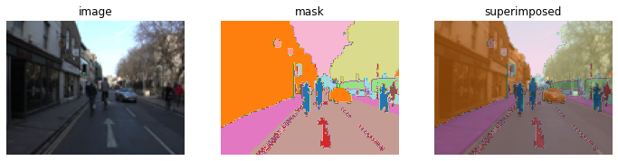

```python
_,axs = plt.subplots(1,3, figsize=(12,3))
cam_img.show(ctx=axs[0], title='image')
mask.show(alpha=1, ctx=axs[1], vmin=1, vmax=30, title='mask')
cam_img.show(ctx=axs[2], title='superimposed')
mask.show(ctx=axs[2], vmin=1, vmax=30);
```

{% endraw %}

### Points

{% raw %}

`class` `TensorPoint`[[source]](https://github.com/fastai/fastai/tree/master/fastai/vision/core.py#L149)

> `TensorPoint`(**`x`**, **`kwargs`) :: `TensorBase`

Basic type for points in an image

{% endraw %} {% raw %}

{% endraw %} {% raw %}

{% endraw %}

Points are expected to come as an array/tensor of shape `(n,2)` or as a list of lists with two elements. Unless you change the defaults in `PointScaler` (see later on), coordinates should go from 0 to width/height, with the first one being the column index (so from 0 to width) and the second one being the row index (so from 0 to height). {% include note.html content='This is different from the usual indexing convention for arrays in numpy or in PyTorch, but it’s the way points are expected by matplotlib or the internal functions in PyTorch like `F.grid_sample`.' %}

{% raw %}

```python
pnt_img = TensorImage(mnist_img.resize((28,35)))
pnts = np.array([[0,0], [0,35], [28,0], [28,35], [9, 17]])
tfm = Transform(TensorPoint.create)
tpnts = tfm(pnts)
test_eq(tpnts.shape, [5,2])
test_eq(tpnts.dtype, torch.float32)
```

{% endraw %} {% raw %}

```python
ctx = pnt_img.show(figsize=(1,1), cmap='Greys')
tpnts.show(ctx=ctx);
```

{% endraw %}

### Bounding boxes

{% raw %}

`get_annotations`[[source]](https://github.com/fastai/fastai/tree/master/fastai/vision/core.py#L170)

> `get_annotations`(**`fname`**, **`prefix`**=*`None`*)

Open a COCO style json in `fname` and returns the lists of filenames (with maybe `prefix`) and labelled bboxes.

{% endraw %} {% raw %}

{% endraw %}

Test `` [`get_annotations`](/vision.core.html#get_annotations) `` on the coco_tiny dataset against both image filenames and bounding box labels.

{% raw %}

```python
coco = untar_data(URLs.COCO_TINY)
test_images, test_lbl_bbox = get_annotations(coco/'train.json')
annotations = json.load(open(coco/'train.json'))
categories, images, annots = map(lambda x:L(x),annotations.values())

test_eq(test_images, images.attrgot('file_name'))

def bbox_lbls(file_name):
    img = images.filter(lambda img:img['file_name']==file_name)[0]
    bbs = annots.filter(lambda a:a['image_id'] == img['id'])
    i2o = {k['id']:k['name'] for k in categories}
    lbls = [i2o[cat] for cat in bbs.attrgot('category_id')]
    bboxes = [[bb[0],bb[1], bb[0]+bb[2], bb[1]+bb[3]] for bb in bbs.attrgot('bbox')]
    return [bboxes, lbls]

for idx in random.sample(range(len(images)),5):
    test_eq(test_lbl_bbox[idx], bbox_lbls(test_images[idx]))
```

{% endraw %} {% raw %}

{% endraw %} {% raw %}

{% endraw %} {% raw %}

`class` `TensorBBox`[[source]](https://github.com/fastai/fastai/tree/master/fastai/vision/core.py#L201)

> `TensorBBox`(**`x`**, **`kwargs`) :: `TensorPoint`

Basic type for a tensor of bounding boxes in an image

{% endraw %} {% raw %}

{% endraw %}

Bounding boxes are expected to come as tuple with an array/tensor of shape `(n,4)` or as a list of lists with four elements and a list of corresponding labels. Unless you change the defaults in `PointScaler` (see later on), coordinates for each bounding box should go from 0 to width/height, with the following convention: x1, y1, x2, y2 where (x1,y1) is your top-left corner and (x2,y2) is your bottom-right corner. {% include note.html content='We use the same convention as for points with x going from 0 to width and y going from 0 to height.' %}

{% raw %}

`class` `LabeledBBox`[[source]](https://github.com/fastai/fastai/tree/master/fastai/vision/core.py#L212)

> `LabeledBBox`(**`items`**=*`None`*, *`rest`, **`use_list`**=*`False`*, **`match`**=*`None`*) :: [`L`](https://fastcore.fast.ai/foundation#L)

Basic type for a list of bounding boxes in an image

{% endraw %} {% raw %}

{% endraw %} {% raw %}

```python
coco = untar_data(URLs.COCO_TINY)
images, lbl_bbox = get_annotations(coco/'train.json')
idx=2
coco_fn,bbox = coco/'train'/images[idx],lbl_bbox[idx]
coco_img = timg(coco_fn)
```

{% endraw %} {% raw %}

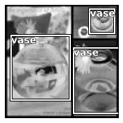

```python
tbbox = LabeledBBox(TensorBBox(bbox[0]), bbox[1])
ctx = coco_img.show(figsize=(3,3), cmap='Greys')
tbbox.show(ctx=ctx);
```

{% endraw %}

## Basic Transforms

Unless specifically mentioned, all the following transforms can be used as single-item transforms (in one of the list in the `tfms` you pass to a `TfmdDS` or a `Datasource`) or tuple transforms (in the `tuple_tfms` you pass to a `TfmdDS` or a `Datasource`). The safest way that will work across applications is to always use them as `tuple_tfms`. For instance, if you have points or bounding boxes as targets and use `Resize` as a single-item transform, when you get to `PointScaler` (which is a tuple transform) you won't have the correct size of the image to properly scale your points.

{% raw %}

{% endraw %} {% raw %}

`encodes`[[source]](https://github.com/fastai/fastai/tree/master/fastai/vision/core.py#L283)

> `encodes`(**`x`**:`TensorBBox`)

{% endraw %} {% raw %}

`encodes`[[source]](https://github.com/fastai/fastai/tree/master/fastai/vision/core.py#L283)

> `encodes`(**`x`**:`TensorBBox`)

{% endraw %} {% raw %}

{% endraw %}

Any data augmentation transform that runs on PIL Images must be run before this transform.

{% raw %}

```python
tfm = ToTensor()
print(tfm)
print(type(mnist_img))
print(type(tfm(mnist_img)))
```

```
ToTensor:
encodes: (PILMask,object) -> encodes
(PILBase,object) -> encodes
decodes:
<class '__main__.PILImageBW'>
<class 'fastai.torch_core.TensorImageBW'>
```

{% endraw %} {% raw %}

```python
tfm = ToTensor()
test_eq(tfm(mnist_img).shape, (1,28,28))
test_eq(type(tfm(mnist_img)), TensorImageBW)
test_eq(tfm(mask).shape, (96,128))
test_eq(type(tfm(mask)), TensorMask)
```

{% endraw %}

Let's confirm we can pipeline this with `PILImage.create`.

{% raw %}

```python
pipe_img = Pipeline([PILImageBW.create, ToTensor()])
img = pipe_img(mnist_fn)
test_eq(type(img), TensorImageBW)
pipe_img.show(img, figsize=(1,1));
```

{% endraw %} {% raw %}

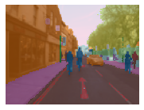

```python
def _cam_lbl(x): return mask_fn
cam_tds = Datasets([cam_fn], [[PILImage.create, ToTensor()], [_cam_lbl, PILMask.create, ToTensor()]])
show_at(cam_tds, 0);
```

{% endraw %}

To work with data augmentation, and in particular the `grid_sample` method, points need to be represented with coordinates going from -1 to 1 (-1 being top or left, 1 bottom or right), which will be done unless you pass `do_scale=False`. We also need to make sure they are following our convention of points being x,y coordinates, so pass along `y_first=True` if you have your data in an y,x format to add a flip. {% include warning.html content='This transform needs to run on the tuple level, before any transform that changes the image size.' %}

{% raw %}

{% endraw %} {% raw %}

`class` `PointScaler`[[source]](https://github.com/fastai/fastai/tree/master/fastai/vision/core.py#L241)

> `PointScaler`(**`do_scale`**=*`True`*, **`y_first`**=*`False`*) :: [`Transform`](https://fastcore.fast.ai/transform#Transform)

Scale a tensor representing points

{% endraw %} {% raw %}

{% endraw %}

To work with data augmentation, and in particular the `grid_sample` method, points need to be represented with coordinates going from -1 to 1 (-1 being top or left, 1 bottom or right), which will be done unless you pass `do_scale=False`. We also need to make sure they are following our convention of points being x,y coordinates, so pass along `y_first=True` if you have your data in an y,x format to add a flip. {% include note.html content='This transform automatically grabs the sizes of the images it sees before a `TensorPoint` object and embeds it in them. For this to work, those images need to be before any points in the order of your final tuple. If you don’t have such images, you need to embed the size of the corresponding image when creating a `TensorPoint` by passing it with `sz=...`.' %}

{% raw %}

```python
def _pnt_lbl(x): return TensorPoint.create(pnts)
def _pnt_open(fn): return PILImage(PILImage.create(fn).resize((28,35)))
pnt_tds = Datasets([mnist_fn], [_pnt_open, [_pnt_lbl]])
pnt_tdl = TfmdDL(pnt_tds, bs=1, after_item=[PointScaler(), ToTensor()])
```

{% endraw %} {% raw %}

```python
test_eq(pnt_tdl.after_item.c, 10)
```

{% endraw %} {% raw %}

```python
x,y = pnt_tdl.one_batch()
#Scaling and flipping properly done
#NB: we added a point earlier at (9,17); formula below scales to (-1,1) coords
test_close(y[0], tensor([[-1., -1.], [-1.,  1.], [1.,  -1.], [1., 1.], [9/14-1, 17/17.5-1]]))
a,b = pnt_tdl.decode_batch((x,y))[0]
test_eq(b, tensor(pnts).float())
#Check types
test_eq(type(x), TensorImage)
test_eq(type(y), TensorPoint)
test_eq(type(a), TensorImage)
test_eq(type(b), TensorPoint)
test_eq(b.img_size, (28,35)) #Automatically picked the size of the input
```

{% endraw %} {% raw %}

```python
pnt_tdl.show_batch(figsize=(2,2), cmap='Greys');
```

{% endraw %} {% raw %}

`class` `BBoxLabeler`[[source]](https://github.com/fastai/fastai/tree/master/fastai/vision/core.py#L262)

> `BBoxLabeler`(**`enc`**=*`None`*, **`dec`**=*`None`*, **`split_idx`**=*`None`*, **`order`**=*`None`*) :: [`Transform`](https://fastcore.fast.ai/transform#Transform)

Delegates (`__call__`,`decode`,`setup`) to (`encodes`,`decodes`,`setups`) if `split_idx` matches

{% endraw %} {% raw %}

{% endraw %} {% raw %}

`decodes`[[source]](https://github.com/fastai/fastai/tree/master/fastai/vision/core.py#L288)

> `decodes`(**`x`**:`TensorBBox`)

{% endraw %} {% raw %}

{% endraw %} {% raw %}

`encodes`[[source]](https://github.com/fastai/fastai/tree/master/fastai/vision/core.py#L283)

> `encodes`(**`x`**:`TensorBBox`)

{% endraw %} {% raw %}

`decodes`[[source]](https://github.com/fastai/fastai/tree/master/fastai/vision/core.py#L288)

> `decodes`(**`x`**:`TensorBBox`)

{% endraw %} {% raw %}

{% endraw %} {% raw %}

```python
def _coco_bb(x):  return TensorBBox.create(bbox[0])
def _coco_lbl(x): return bbox[1]

coco_tds = Datasets([coco_fn], [PILImage.create, [_coco_bb], [_coco_lbl, MultiCategorize(add_na=True)]], n_inp=1)
coco_tdl = TfmdDL(coco_tds, bs=1, after_item=[BBoxLabeler(), PointScaler(), ToTensor()])
```

{% endraw %} {% raw %}

```python
Categorize(add_na=True)
```

```
Categorize -- {'vocab': None, 'sort': True, 'add_na': True}:
encodes: (object,object) -> encodes
decodes: (object,object) -> decodes
```

{% endraw %} {% raw %}

```python
coco_tds.tfms
```

```
(#3) [Pipeline: PILBase.create,Pipeline: _coco_bb,Pipeline: _coco_lbl -> MultiCategorize -- {'vocab': None, 'sort': True, 'add_na': True}]
```

{% endraw %} {% raw %}

```python
x,y,z
```

[output not shown]

{% endraw %} {% raw %}

```python
x,y,z = coco_tdl.one_batch()
test_close(y[0], -1+tensor(bbox[0])/64)
test_eq(z[0], tensor([1,1,1]))
a,b,c = coco_tdl.decode_batch((x,y,z))[0]
test_close(b, tensor(bbox[0]).float())
test_eq(c.bbox, b)
test_eq(c.lbl, bbox[1])

#Check types
test_eq(type(x), TensorImage)
test_eq(type(y), TensorBBox)
test_eq(type(z), TensorMultiCategory)
test_eq(type(a), TensorImage)
test_eq(type(b), TensorBBox)
test_eq(type(c), LabeledBBox)
test_eq(y.img_size, (128,128))
```

{% endraw %} {% raw %}

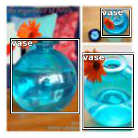

```python
coco_tdl.show_batch();
```

{% endraw %}